# act_report

## Act Report: pdf

WeRateDogs (https://twitter.com/dog_rates) is a Twitter account that is well known for its pictures and commentary of dogs. Its popularity is built on the internet's obsession with dogs, a rating system that reflects how good all dogs are with scores consistently above the maximum, and commentary that has spawned a language of its own through observations about the pictures and both amusing remarks to other user accounts. I've combed through thousands of this account's tweets to find some of the patterns in their postings.

Not all tweets had ratings, and not all ratings were of dogs. Of all ratings, the average numerator is 13.22, and out of all dog ratings, the average numerator is 11.6. While the denominators in the ratings were most often 10, this wasn't always the case. Of all ratings, the average ratio of numerator over denominator is infinity, while the same for the ratings of dogs was 1.1. The highest numerator overall is 1776, while the lowest is 0.0. Also the highest denominator overall is 170, while the lowest is 0.0.

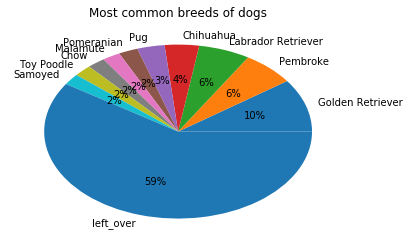

| Dog Breed | Values |
| --- | --- |
| Golden Retriever | 119 |
| Pembroke | 77 |
| Labrador Retriever | 75 |
| Chihuahua | 50 |
| Pug | 39 |
| Pomeranian | 28 |
| Toy Poodle | 26 |
| Malamute | 26 |
| Chow | 26 |
| Samoyed | 25 |

Some breeds were more popular than others. Golden Retrievers, Pembroke, Labrador Retrievers, and Chihuahua were the most common. Meanwhile, Clumber, Groenendael, Standard schnauzer, Irish water spaniel, and Scotch terrier were the least common, with only a single rating(1) each. It seems that more popular breeds of dogs are rated more often than less popular breeds.

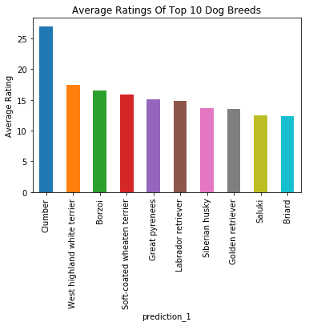

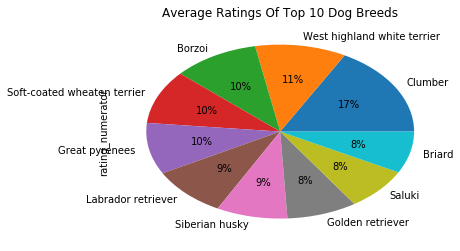

| Dog Breed | Average Numerator Rating |
| --- | --- |
| Clumber | 27.00 |
| West Highland White Terrier | 17.45 |
| Borzoi | 16.50 |
| Soft-Coated Wheaten Terrier | 15.90 |
| Great Pyrenees | 15.15 |
| Labrador Retriever | 14.77 |
| Siberian Husky | 13.64 |
| Golden Retriever | 13.47 |
| Saluki | 12.50 |
| Briard | 12.33 |

Out of all breeds, the Clumber, the West Highland White Terrier, the Borzoi, Soft-Coated Wheaten Terrier, and the Great Pyrenees had the highest average numerator rating. Meanwhile, the Japanese Spaniel had the lowest average numerator rating of 5, followed by the Afghan Hound at 8, and the Boston Bull at an average of 8.7.